# Lab 6

Author

Giuliet Kibler

# Learning goals

- Use `unnest_tokens()` and `unnest_ngrams()` to extract tokens and ngrams from text.
- Use dplyr and ggplot2 to analyze text data

# Lab description

For this lab we will be working with a new dataset. The dataset contains transcription samples from https://www.mtsamples.com/. And is loaded and “fairly” cleaned at https://raw.githubusercontent.com/USCbiostats/data-science-data/master/00_mtsamples/mtsamples.csv.

### Setup packages

You should load in `dplyr`, (or `data.table` if you want to work that way), `ggplot2` and `tidytext`. If you don’t already have `tidytext` then you can install with

```r
install.packages("tidytext")
```

### read in Medical Transcriptions

Loading in reference transcription samples from https://www.mtsamples.com/

```r
library(readr)
library(dplyr)
library(tidytext)
library(ggplot2)
library(tibble)
library(stringr)
library(tidyr)
mt_samples <- read_csv("https://raw.githubusercontent.com/USCbiostats/data-science-data/master/00_mtsamples/mtsamples.csv")
mt_samples <- mt_samples |>
  select(description, medical_specialty, transcription)

head(mt_samples)
```

```
# A tibble: 6 × 3
  description                                    medical_specialty transcription
  <chr>                                          <chr>             <chr>
1 A 23-year-old white female presents with comp… Allergy / Immuno… "SUBJECTIVE:…
2 Consult for laparoscopic gastric bypass.       Bariatrics        "PAST MEDICA…
3 Consult for laparoscopic gastric bypass.       Bariatrics        "HISTORY OF …
4 2-D M-Mode. Doppler.                           Cardiovascular /… "2-D M-MODE:…
5 2-D Echocardiogram                             Cardiovascular /… "1.  The lef…
6 Morbid obesity.  Laparoscopic antecolic anteg… Bariatrics        "PREOPERATIV…
```

## Question 1: What specialties do we have?

We can use `count()` from `dplyr` to figure out how many different catagories do we have? Are these catagories related? overlapping? evenly distributed?

```r
mt_samples |>
  count(medical_specialty, sort = TRUE)
```

```
# A tibble: 40 × 2
   medical_specialty                 n
   <chr>                         <int>
 1 Surgery                        1103
 2 Consult - History and Phy.      516
 3 Cardiovascular / Pulmonary      372
 4 Orthopedic                      355
 5 Radiology                       273
 6 General Medicine                259
 7 Gastroenterology                230
 8 Neurology                       223
 9 SOAP / Chart / Progress Notes   166
10 Obstetrics / Gynecology         160
# ℹ 30 more rows
```

There are 40 specialties. Some specialties seem to overlap, like allergy/immunology and diets and nutrition, as well as dermatology and cosmetic/plastic surgery. The specialties are not evenly distributed with surgery having the highest count, 1103, and hospice having the smallest count, 6.

## Question 2

- Tokenize the the words in the `transcription` column
- Count the number of times each token appears
- Visualize the top 20 most frequent words

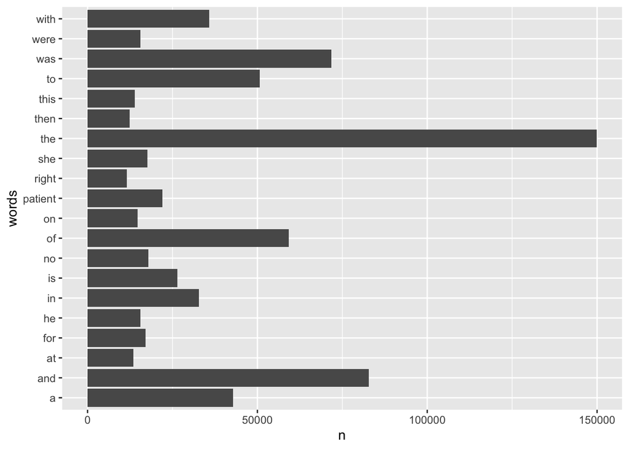

  ```r
  mt_samples |>
    unnest_tokens(words, transcription, token = "words") |>
    count(words, sort = TRUE) |>
    top_n(20, n) |>
    ggplot(aes(n, words)) +
    geom_col()
  ```

  ```r
  print(words)
  ```

  [output cut: 181 more lines]

Explain what we see from this result. Does it makes sense? What insights (if any) do we get?

The top word is the, followed by and and was. We don’t gain much insight because most of the top 20 words are stop words, which makes sense because of grammatical structure. Patient may be the only useful word.

## Question 3

- Redo visualization but remove stopwords before
- Bonus points if you remove numbers as well

  ```r
  # Remove stop words
  words_clean <- mt_samples |>
    unnest_tokens(words, transcription, token = "words") |>
    anti_join(stop_words, by = c("words" = "word")) |>
    count(words, sort = TRUE)

  print(words_clean)
  ```

  ```
  # A tibble: 23,025 × 2
     words         n
     <chr>     <int>
   1 patient   22065
   2 left      11258
   3 history    9509
   4 2          8864
   5 1          8396
   6 normal     7526
   7 procedure  7463
   8 3          6093
   9 pain       5976
  10 4          5318
  # ℹ 23,015 more rows
  ```

What do we see know that we have removed stop words? Does it give us a better idea of what the text is about?

Patient is now the top word, followed by left and history. This better explains the medical data because these are medical terms.

# Question 4

repeat question 2, but this time tokenize into bi-grams. how does the result change if you look at tri-grams?

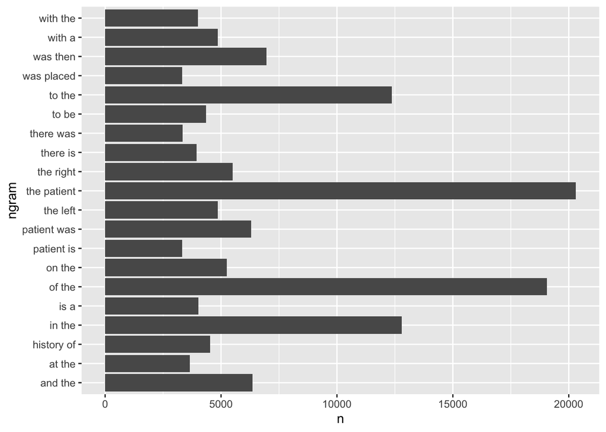

```r
# Bi-gram
mt_samples |>
  unnest_tokens(ngram, transcription, token = "ngrams", n = 2) |>
  count(ngram, sort = TRUE) |>
  top_n(20, n) |>
  ggplot(aes(n, ngram)) +
  geom_col()
```

“The patient” is now the top bi-gram, followed by “of the” and “in the”. This is relatively useless because of the stop words.

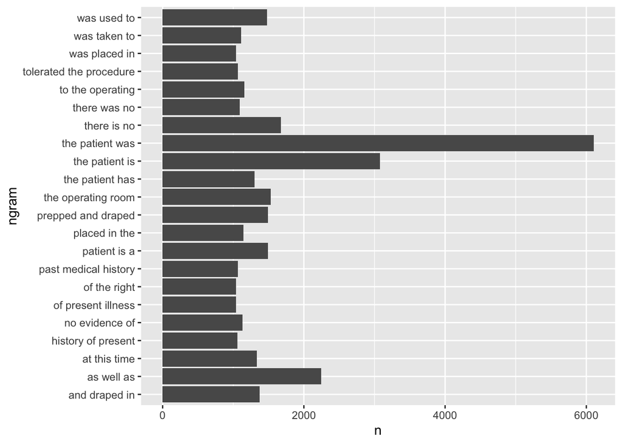

```r
# Tri-gram
mt_samples |>
  unnest_tokens(ngram, transcription, token = "ngrams", n = 3) |>
  count(ngram, sort = TRUE) |>
  top_n(20, n) |>
  ggplot(aes(n, ngram)) +
  geom_col()
```

“The patient was” is the most common tri-gram followed by “the patient is”. This makes sense in conjunction with the bi-gram the patient being the top phrase. Again, these phrases are relatively useless because of the stop words, but patient at least puts us in a medical frame.

# Question 5

Using the results you got from questions 4. Pick a word and count the words that appears after and before it.

```r
# Target word is history
target_word = "history"

ngrams <- mt_samples |>
  unnest_tokens(ngram, transcription, token = "ngrams", n = 2)

# Seperate into cases of before and after
before_after <- ngrams |>
  filter(str_detect(ngram, target_word)) |>
  separate(ngram, into = c("word_before", "word_after"), sep = " ") |>
  mutate(word_before = ifelse(word_before == target_word, NA, word_before),
         word_after = ifelse(word_after == target_word, NA, word_after))

# Count occurrences of words before and after the target word
count_before <- before_after |>
  filter(!is.na(word_before)) |>
  count(word_before, sort = TRUE)
count_after <- before_after |>
  filter(!is.na(word_after)) |>
  count(word_after, sort = TRUE)

print(count_before)
```

```
# A tibble: 566 × 2
   word_before     n
   <chr>       <int>
 1 medical      1223
 2 family        941
 3 a             939
 4 social        865
 5 surgical      491
 6 no            473
 7 with          163
 8 any           129
 9 brief         125
10 the           107
# ℹ 556 more rows
```

```r
print(count_after)
```

```
# A tibble: 368 × 2
   word_after          n
   <chr>           <int>
 1 of               4537
 2 the               761
 3 she               279
 4 he                227
 5 significant       200
 6 this              200
 7 and               197
 8 1                 181
 9 is                172
10 noncontributory   121
# ℹ 358 more rows
```

# Question 6

Which words are most used in each of the specialties. you can use `group_by()` and `top_n()` from `dplyr` to have the calculations be done within each specialty. Remember to remove stopwords. How about the most 5 used words?

```r
mt_samples |>
  unnest_tokens(words, transcription, token = "words") |>
  anti_join(stop_words, by = c("words" = "word")) |>
  group_by(medical_specialty) |>
  count(words, sort = TRUE) |>
  top_n(5, n)
```

```
# A tibble: 209 × 3
# Groups:   medical_specialty [40]
   medical_specialty          words         n
   <chr>                      <chr>     <int>
 1 Surgery                    patient    4855
 2 Surgery                    left       3263
 3 Surgery                    procedure  3243
 4 Consult - History and Phy. patient    3046
 5 Consult - History and Phy. history    2820
 6 Surgery                    0          2094
 7 Surgery                    1          2038
 8 Orthopedic                 patient    1711
 9 Cardiovascular / Pulmonary left       1550
10 Cardiovascular / Pulmonary patient    1516
# ℹ 199 more rows
```

The most used word, regardless of specialty, appear to be patient.

# Question 7 - extra

Find your own insight in the data:

Ideas:

- Interesting ngrams
- See if certain words are used more in some specialties then others

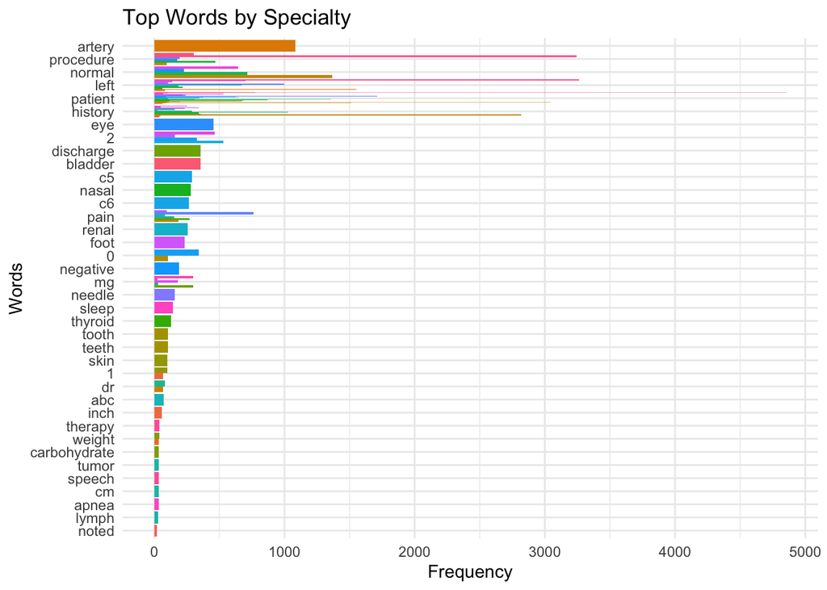

  ```r
  # See if certain words are used more in some specialties then others
  word_counts <- mt_samples |>
    unnest_tokens(word, transcription) |>
    anti_join(stop_words, by = c("word" = "word")) |>
    count(medical_specialty, word, sort = TRUE)

  # Step 2: Find top words per specialty
  top_words <- word_counts |>
    group_by(medical_specialty) |>
    top_n(3, n) |>
    ungroup()

  # Step 3: Visualize the results
  ggplot(top_words, aes(x = reorder(word, n), y = n, fill = medical_specialty)) +
    geom_col(position = "dodge", show.legend = FALSE) +
    labs(x = "Words", y = "Frequency", title = "Top Words by Specialty") +
    coord_flip() +
    theme_minimal() +
    theme(legend.position = "top")
  ```